# Part 1: Explanatory analysis of the dataset

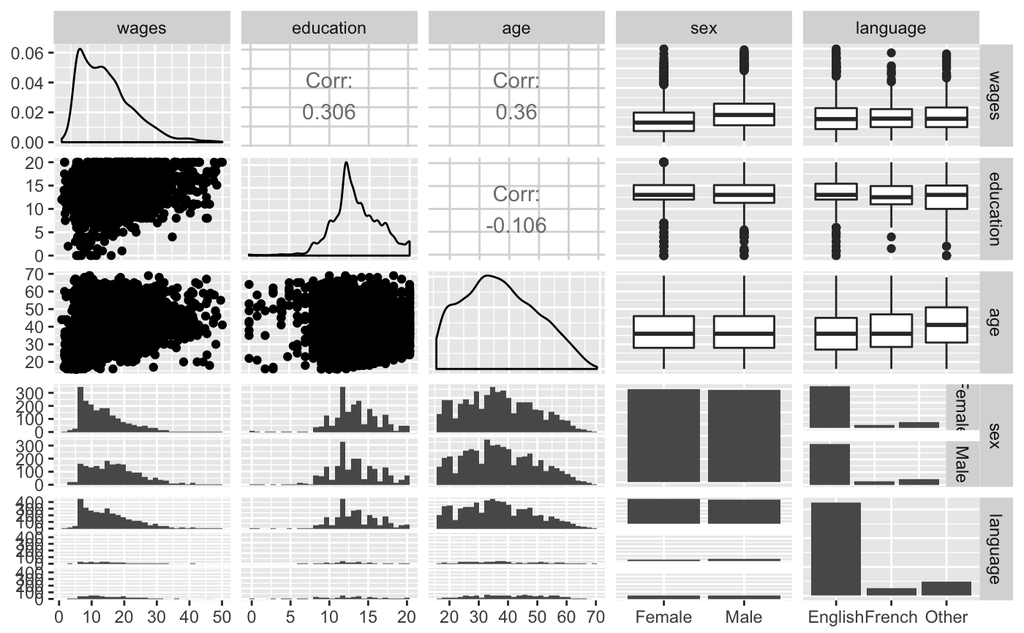

Draw a matrix of diagnostic plots of all the variables and comment briefly on the relationship between some of the variables.

`Wage` has a positive correlation with the quantitative variables `education` and `age`. In addition we see that `sex`=“Male” has a positive effect on `Wage`. Increasing `education`, `age` or switching `sex` to “Male” will, on average, result in an increase in `Wage` in our dataset.

We want to study how the qualitative variable wages depends on one or more explanatory variables. Which assumptions do we need make about the data if we want to perform a multiple linear regression analysis?

TASK 2a We develop our `mylm` to estimate the coefficients using the least squares estimator
$$\hat{\beta} = (X^T X)^{-1} X^T Y$$
And confirm that this results in the same coefficient estimates as the included `lm` function

```r
library(mylm)
model1 = mylm(wages ~ education, data=SLID)
print(model1)
```

```
Call:
mylm(formula = wages ~ education, data = SLID)

Coefficients:
     (Intercept) education
[1,]    4.971691 0.7923091
```

```r
model2 = lm(wages ~education, data=SLID)
print(model2)
```

```
Call:
lm(formula = wages ~ education, data = SLID)

Coefficients:
(Intercept)    education
     4.9717       0.7923
```

TASK 2b As $\beta = (X^T X)^{-1} X^T Y$ is a linear transformation of $Y$ and $Cov(Y) = \sigma^2 I$,
$$Cov(\beta) = (X^T X)^{-1} X^T Cov(Y) X (X^T X)^{-1} = (X^T X)^{-1} \sigma^2$$
As we have also assumed that $Y \sim N(\beta X, \sigma^2)$, we get that
$$\hat{\beta} \sim N(\beta, (X^T X)^{-1} \sigma^2)$$

We can then test the significance of the coefficients by computing the test statistics
$$z_j = \frac{(\beta_j - 0)}{ (c_{jj} \sigma^2)}, \quad c_{jj} = Cov(\beta)_{jj}$$
And the corresponding p-values
$$p_j = 2 Pr(Z \geq | z_j |)$$
Note that we in `mylm` assume asymptotic results ($n - p$ very large) and we can then use the approximation $\hat{\sigma}^2 = \sigma^2$ without using the t-distribution.

Task2c

In `mylm` we implement the plot function as a comparison of the fitted values and the residuals. This should show no structure

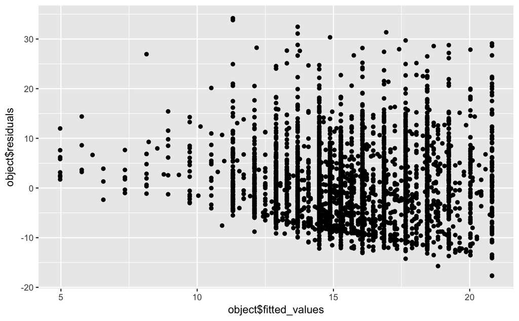

```r
plot(model1)
```

Task2d

The residual sum of squares `SSE` is the sum of squares $\sum^n (y_i - \hat{y}_i)^2$. The degrees of freedom for this model is the number of observations minus the number of fitted parameters, $n - p$. The total sum of squares similarly defined as $\sum^n (y_i - \bar{y})^2$. Under $H_0$, i.e. the response is uncorrelated with all covariates,
$$\frac{(SST - SSE) / (p-1)}{SSE / (n - p)} \sim F_{p-1, n-p}$$
Again we assume that $(n - p) \rightarrow \infty$ results and get
$$\frac{(SST - SSE)}{SSE / (n-p)} \sim \chi^2_{p-1}$$
Which we can use to test the significance of the total regression.

```r
cat("Chi-square test statistic: ", model1$F_statistic, "\n")
```

```
Chi-square test statistic:  411.4471
```

```r
cat("p-val: ", model1$F_p_val)
```

```
p-val:  2e-16
```

```r
interval = c(0.70, 0.85, 0.90, 0.95)
interval2 = c(0.40, 0.60, 0.80, 0.90)
cat(abs(qnorm(interval)), "\n")
```

```
0.5244005 1.036433 1.281552 1.644854
```

```r
cat(sqrt(qchisq(interval2, 1)))
```

```
0.5244005 0.8416212 1.281552 1.644854
```

Task2e

The coefficient of determination $R^2$ is the proportion of variance explained by the regression. It is the square of the sample correlation between $y$ and $\hat{Y}$.
$$R^2 = \frac{SSR}{SST} = 1 - \frac{SSE}{SST}$$

Task3a

```r
model2 = mylm(wages ~ education + age, data = SLID)
summary(model2)
```

```
Summary of object
Call:
mylm(formula = wages ~ education + age, data = SLID)

Residuals:
         0%         25%         50%         75%        100%
-24.3030226  -4.4950673  -0.8070213   3.6736376  37.6279284

Coefficients:
            Estimate Std. Error z value Pr(>|z|)
(Intercept)  -6.0217   0.618924  -9.729    2e-16 ***
education     0.9015   0.035760  25.209    2e-16 ***
age           0.2571   0.008951  28.721    2e-16 ***
Signif. codes:  0 '***' 0.001 '**' 0.01 '*' 0.05 '.' 0.1 ' ' 1

Residual Standard Error: 6.8 on 3984 degrees of freedom
Multiple R-squared: 0.2491    Adjusted R-squared: 0.24869
Chisq-statisic: 661 on 2 degrees of freedom, p-value: 2e-16
```

Task3b

```r
model20 = mylm(wages ~ education, data=SLID)
model21 = mylm(wages ~ age, data=SLID)
summary(model20)
```

```
Summary of object
Call:
mylm(formula = wages ~ education, data = SLID)

Residuals:
        0%        25%        50%        75%       100%
-17.687873  -5.822482  -1.039400   4.147527  34.189836

Coefficients:
            Estimate Std. Error z value Pr(>|z|)
(Intercept)   4.9717    0.53429   9.305    2e-16 ***
education     0.7923    0.03906  20.284    2e-16 ***
Signif. codes:  0 '***' 0.001 '**' 0.01 '*' 0.05 '.' 0.1 ' ' 1

Residual Standard Error: 7.5 on 3985 degrees of freedom
Multiple R-squared: 0.09359    Adjusted R-squared: 0.093359
Chisq-statisic: 411 on 1 degrees of freedom, p-value: 2e-16
```

```r
summary(model21)
```

```
Summary of object
Call:
mylm(formula = wages ~ age, data = SLID)

Residuals:
        0%        25%        50%        75%       100%
-17.747375  -4.847109  -1.506569   3.913970  35.063157

Coefficients:
            Estimate Std. Error z value Pr(>|z|)
(Intercept)   6.8909   0.374047   18.42    2e-16 ***
age           0.2331   0.009583   24.33    2e-16 ***
Signif. codes:  0 '***' 0.001 '**' 0.01 '*' 0.05 '.' 0.1 ' ' 1

Residual Standard Error: 7.3 on 3985 degrees of freedom
Multiple R-squared: 0.1293    Adjusted R-squared: 0.12907
Chisq-statisic: 592 on 1 degrees of freedom, p-value: 2e-16
```

Why and when does the parameter estimates found (using two simple and one multiple) differ?

Task4

```r
model30 = mylm(wages ~ sex + age + language + I(education^2), data=SLID)
summary(model30)
```

```
Summary of object
Call:
mylm(formula = wages ~ sex + age + language + I(education^2),
    data = SLID)

Residuals:
         0%         25%         50%         75%        100%
-27.1711960  -4.2761844  -0.7631001   3.2176183  35.9289483

Coefficients:
               Estimate Std. Error z value  Pr(>|z|)
(Intercept)    -1.87553   0.440345 -4.2592 2.051e-05 ***
sexMale         3.40870   0.208420 16.3550 2.000e-16 ***
age             0.24862   0.008663 28.7009 2.000e-16 ***
languageFrench -0.07553   0.425136 -0.1777 8.590e-01
languageOther  -0.13454   0.323153 -0.4163 6.772e-01
I(education^2)  0.03482   0.001290 26.9907 2.000e-16 ***
Signif. codes:  0 '***' 0.001 '**' 0.01 '*' 0.05 '.' 0.1 ' ' 1

Residual Standard Error: 6.6 on 3981 degrees of freedom
Multiple R-squared: 0.3022    Adjusted R-squared: 0.30134
Chisq-statisic: 345 on 5 degrees of freedom, p-value: 2e-16
```

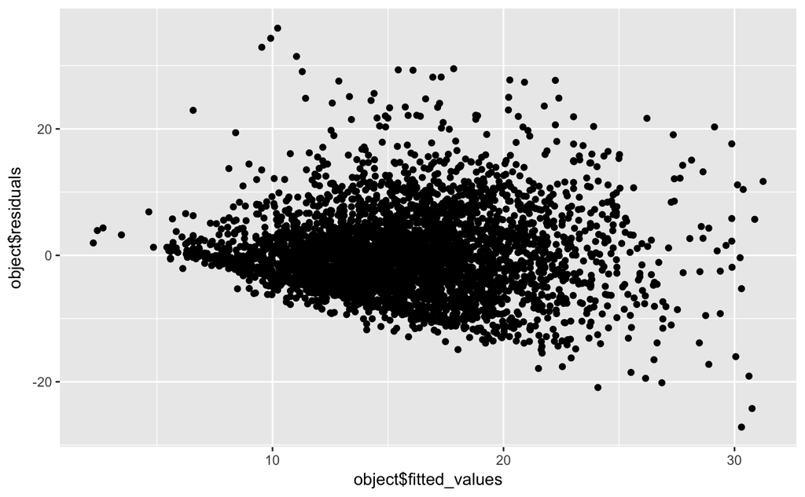

```r
plot(model30)
```

```r
model31 = mylm(wages ~ language + education + language*education, data=SLID)
summary(model31)
```

```
Summary of object
Call:
mylm(formula = wages ~ language + education + language * education,
    data = SLID)

Residuals:
         0%         25%         50%         75%        100%
-16.4938410  -5.6930927  -0.9909205   4.1249151  34.4622671

Coefficients:
                         Estimate Std. Error z value  Pr(>|z|)
(Intercept)                3.6050    0.64087   5.625 1.854e-08 ***
languageFrench             4.2548    2.05958   2.066 3.884e-02   *
languageOther              4.4063    1.27818   3.447 5.661e-04 ***
education                  0.8816    0.04653  18.946 2.000e-16 ***
languageFrench:education  -0.2934    0.15373  -1.908 5.633e-02   .
languageOther:education   -0.2544    0.09580  -2.655 7.928e-03  **
Signif. codes:  0 '***' 0.001 '**' 0.01 '*' 0.05 '.' 0.1 ' ' 1

Residual Standard Error: 7.5 on 3981 degrees of freedom
Multiple R-squared: 0.09798    Adjusted R-squared: 0.096844
Chisq-statisic: 86 on 5 degrees of freedom, p-value: 2e-16
```

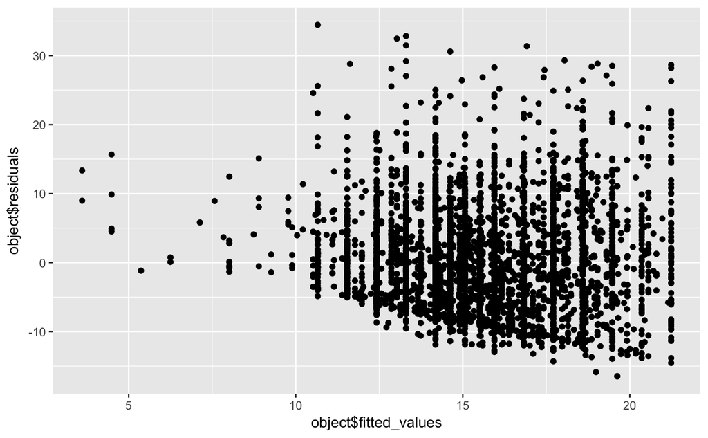

```r
plot(model31)
```

```r
model32 = mylm(wages ~ education - 1, data=SLID)
summary(model32)
```

[output not shown]

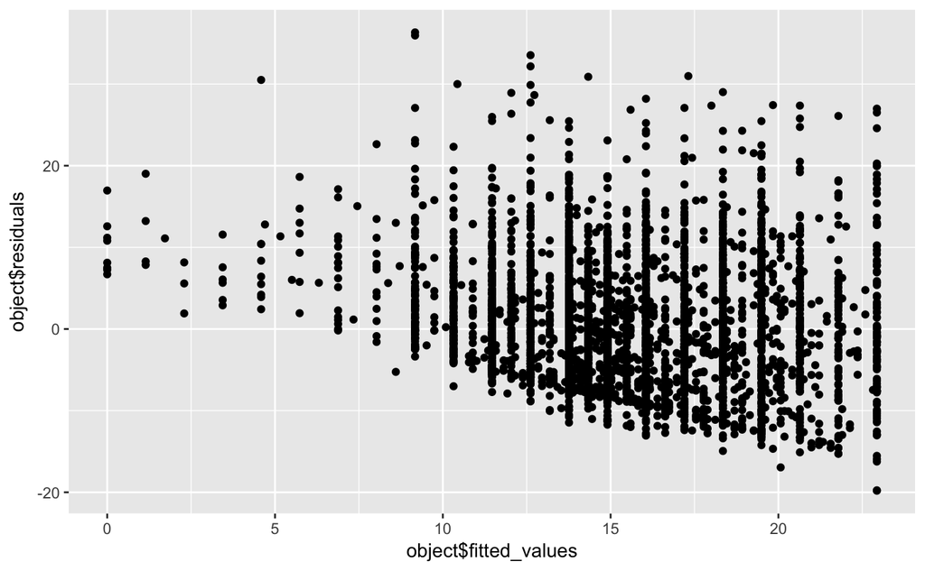

```r
plot(model32)
```